# Random Forest Modeling for Predicting Outcome Class of Human Activity Recognition Data

Author: Julia Phelps

June 2nd, 2016

## **Overview**

This analysis attempts to use Human Activity Recognition data from http://groupware.les.inf.puc-rio.br/har to maximize the accuracy of outcome class prediction on a large scale. Through utilization of Random Forest techniques, combined with structured feature selection and K-fold Cross-Validation, the analysis is able to predict outcomes with an accuracy of ~99% or greater. This analysis was produced to satisfy Course Project requirements for the class *Practical Machine Learning*, offered through [Coursera.org](http://www.coursera.org).

## **Load Required Packages and Data Sets**

There are several packages necessary for this analysis, which include `caret`, `randomForest`, `parallel`, `doParallel`,`pander`, `ggplot2`, and `Cairo`. The original `index.Rmd` file will attempt to load these packages in the background. If you do not already have them installed on your machine, please see *Appendix: ii.* for the installation code.

```r
## if necessary, download data into working directory
if(!file.exists("pml-training.csv")){
    download.file(url="https://d396qusza40orc.cloudfront.net/predmachlearn/pml-training.csv",
                  destfile="pml-training.csv", mode="wb")
}
if(!file.exists("pml-testing.csv")){
    download.file(url="https://d396qusza40orc.cloudfront.net/predmachlearn/pml-testing.csv",
                  destfile="pml-testing.csv", mode="wb")
}

## import data into R
trainRaw <- read.csv(file="pml-training.csv")
testRaw <- read.csv(file="pml-testing.csv")
```

## **Description of Data and Goal of Prediction Analysis**

The data provided by Coursera.org for this analysis originally comes from http://groupware.les.inf.puc-rio.br/har, as described in the paper **Qualitative Activity Recognition of Weight Lifting Exercises** (*see Appendix: i.*). The original goal of the study was to define, via qualitative measurements from sensors placed on the body, how “well” (in other words, accurately) a subject performed a given exercise. In the study, the researchers gathered measurements from four key areas of the body while the subjects performed repetitions of the Unilateral Dumbbell Biceps Curl exercise, and then attempted to classify them into one of five categories.

The subset of this data that is provided to us is composed of a training set with 19622 observations of 160 variables, and a testing set with 20 observations and 160 variables. The data in each is a mix of numeric, integer, and factor variables. In the training set, the outcome `'classe'` is as follows:

| Class | Frequency | Description |
| --- | --- | --- |
| A | 5580 | exactly according to description |
| B | 3797 | throwing the elbows to the front |
| C | 3422 | lifting the dumbbell only halfway |
| D | 3216 | lowering the dumbbell only halfway |
| E | 3607 | throwing the hips to the front |

The goal of this analysis is to use Machine Learning techniques to accurately predict the class of each activity, using any or all of the variables provided and a method of our choosing.

## **Exploration and Selection of Features**

Since the data has numerous variables, our first task is to explore the data and determine what features will be most useful for prediction. A simple comparison of variable names between the `trainRaw` and `testRaw` data sets reveals that the first 159 variables in each set are the same. However, the 160th variable in the `trainRaw` set is `'classe'`, which has the Class outcomes for its observations, while the 160th variable in the `testRaw` set is `'problem_id'`, which will be used to grade final prediction results. To make our feature selection process easier, let’s split out the two different variables from their respective sets.

```r
train_classe <- trainRaw$classe
trainRaw <- trainRaw[,-160]
test_problem_id <- testRaw$problem_id
testRaw <- testRaw[,-160]
```

#### **1. NA values**

Next, let’s look at how much of the data in our `trainRaw` set is complete.

```r
pandoc.table(table(is.na(trainRaw)))
```

| FALSE | TRUE |
| --- | --- |
| 1832426 | 1287472 |

In `trainRaw`, ~41% of the values are NA. Let’s take a look at how many variables contain these NA values.

```r
train_isNA <- sapply(trainRaw, function(x) sum(is.na(x)))
pandoc.table(table(train_isNA))
```

| 0 | 19216 |
| --- | --- |
| 92 | 67 |

There are 67 variables within the data set where 19216 out of 19622 observations are missing. Given the large proportion (~98%) of NA values in these variables, it does not make sense to try to include them as features when we build our prediction algorithm. However, since we will eventually want to apply this model to the values in our test set, we should also check to see how many of its variables contain NA values.

```r
test_isNA <- sapply(testRaw, function(x) sum(is.na(x)))
pandoc.table(table(test_isNA))
```

| 0 | 20 |
| --- | --- |
| 59 | 100 |

Only 59 of the variables in the `testRaw` data set contain values; the rest are entirely NA. Let’s check and see which variables in `test_isNA` are also contained in `train_isNA`.

```r
train_nonNA <- names(train_isNA[train_isNA==0])
test_nonNA <- names(test_isNA[test_isNA==0])
sum(test_nonNA %in% train_nonNA)
```

```
## [1] 59
```

Since all 59 of the non-NA variables in `test_isNA` are also in the non-NA variables of `train_isNA`, we will only keep the 59 variables in `test_isNA`.

```r
train <- trainRaw[,test_nonNA]
test <- testRaw[,test_nonNA]
```

#### **2. Selecting features**

Description of the various measurements made in this dataset can be found in the paper **Qualitative Activity Recognition of Weight Lifting Exercises** (*see Appendix: i.*). The data set is comprised of various quantitative measurements taken while performing a Unilateral Dumbbell Biceps Curl from four key areas of the body: Armband (indicated as ‘arm’), Glove (indicated as ‘forearm’), Lumbar Belt (indicated as ‘belt’), and Dumbbell. For the purposes of our prediction algorithm, we will focus on measurements from these four areas.

```r
head(names(train), 10)
```

```
##  [1] "X"                    "user_name"            "raw_timestamp_part_1"
##  [4] "raw_timestamp_part_2" "cvtd_timestamp"       "new_window"
##  [7] "num_window"           "roll_belt"            "pitch_belt"
## [10] "yaw_belt"
```

Given that the variable that we are trying to predict, `'classe'`, does not necessarily depend on a time series, we will subset out the 3 ‘timestamp’ variables and the ‘window’ variables, as well as the `'X'` (row number) and `'user_name'` (subject name) variables in both of our data sets.

```r
train <- train[,8:59]
test <- test[,8:59]
```

We are left with a total of 52 features in our training set, which we will use to build our prediction algorithm.

#### **3. Splitting into ‘training’ and ‘validation’ sets**

In order to get a better estimate of accuracy of our prediction algorithm before we apply it to the final `'test'` set, it will be helpful to subset our `'train'` data set into `'training'` and `'validation'` sets. Before we subset the `'train'` data, we can add our outcome variable `'classe'` back into the set:

```r
train$classe <- train_classe
set.seed(53535)
inTraining <- createDataPartition(y=train$classe, p=0.8, list=FALSE)
training <- train[inTraining,]
validation <- train[-inTraining,]
```

Our `training` set, which we will use to build our model, includes of 15699 observations. We will use the smaller `validation` set, consisting of 3923 observations, to get a more accurate measure of Out-of-Sample prediction accuracy.

## **Training the Model**

We have a considerable number of features to predict on, even after subsetting. With this in mind, the Random Forest method is a good choice for training our model because it can accurately handle a large number of predictors.

However, Random Forest algorithms can be very computationally-intensive. To help alleviate this problem, we will employ parallel implementation of our model across multiple cores. Likewise, we will use K-Fold Cross Validation (rather than the default bootstrap method) in order to improve computation efficiency. Although K-Fold Cross-Validation can be less accurate, it does not appear to significantly detract from our prediction accuracy in this case. Lastly, we will split our data into predictors and outcomes, which has been shown to have a positive effect on computational time (as opposed to using a single data.frame).

```r
training_x <- training[,-53]
training_y <- training[,53]
cluster <- makeCluster(detectCores()-1)
registerDoParallel(cluster)
trainingControl <- trainControl(method="cv", number=5, allowParallel=TRUE)
trainingFit <- train(training_x, training_y, method="rf", data=training,
                     trControl=trainingControl)
stopCluster(cluster)
```

Let’s take a look at our model fit:

```
## Random Forest
##
## 15699 samples
##    52 predictor
##     5 classes: 'A', 'B', 'C', 'D', 'E'
##
## No pre-processing
## Resampling: Cross-Validated (5 fold)
## Summary of sample sizes: 12559, 12558, 12561, 12559, 12559
## Resampling results across tuning parameters:
##
##   mtry  Accuracy   Kappa
##    2    0.9917831  0.9896053
##   27    0.9902537  0.9876701
##   52    0.9859858  0.9822693
##
## Accuracy was used to select the optimal model using  the largest value.
## The final value used for the model was mtry = 2.
```

The In-Sample Accuracy for the final model, `mtry=2`, is ~99.2%. We can also look at Variable Importance to see which of our features were the most important to classifying our predictions.

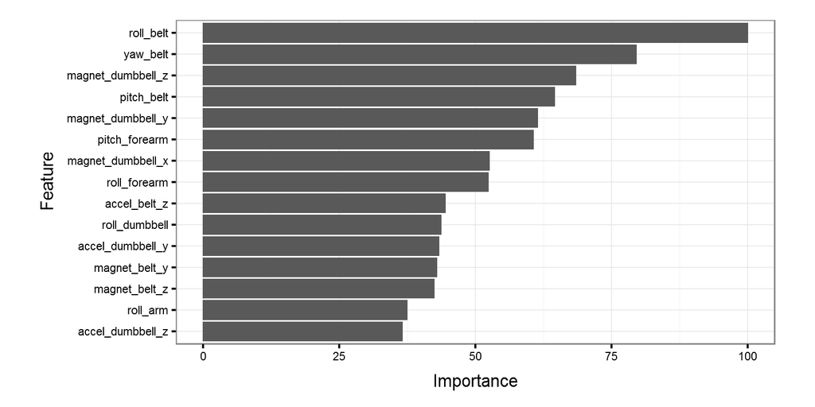

## **Out-of-Sample Error**

To get a better idea of the Out-of-Sample Error before we apply the model to the `test` set, let’s check it with the `validation` set:

```r
validation_x <- validation[,-53]
validation_trueOutcome <- validation[,53]
validation_pred <- predict(trainingFit, validation_x)
confusionMatrix(validation_pred, validation_trueOutcome)
```

```
## Confusion Matrix and Statistics
##
##           Reference
## Prediction    A    B    C    D    E
##          A 1116    0    0    0    0
##          B    0  759    2    0    0
##          C    0    0  682    6    0
##          D    0    0    0  636    0
##          E    0    0    0    1  721
##
## Overall Statistics
##
##                Accuracy : 0.9977
##                  95% CI : (0.9956, 0.999)
##     No Information Rate : 0.2845
##     P-Value [Acc > NIR] : < 2.2e-16
##
##                   Kappa : 0.9971
##  Mcnemar's Test P-Value : NA
##
## Statistics by Class:
##
##                      Class: A Class: B Class: C Class: D Class: E
## Sensitivity            1.0000   1.0000   0.9971   0.9891   1.0000
## Specificity            1.0000   0.9994   0.9981   1.0000   0.9997
## Pos Pred Value         1.0000   0.9974   0.9913   1.0000   0.9986
## Neg Pred Value         1.0000   1.0000   0.9994   0.9979   1.0000
## Prevalence             0.2845   0.1935   0.1744   0.1639   0.1838
## Detection Rate         0.2845   0.1935   0.1738   0.1621   0.1838
## Detection Prevalence   0.2845   0.1940   0.1754   0.1621   0.1840
## Balanced Accuracy      1.0000   0.9997   0.9976   0.9946   0.9998
```

We get a prediction accuracy of 0.9977 (~99.8%) on our validation set, with a 95% confidence interval of (0.9956, 0.999), so we can feel pretty confident about our Random Forest model’s ability to predict on new data.

## **Conclusion: Applying the Model to the Test Set**

The last thing that we need to do is to apply our model fit to the provided `test` set.

```r
test_pred <- predict(trainingFit, test)
test_pred
```

```
##  [1] B A B A A E D B A A B C B A E E A B B B
## Levels: A B C D E
```

This prediction was verified as 100% accurate, based on the Course Project Prediction Quiz (on Coursera.org). Limiting our features to less than one-third of the original set, combined with a Random Forest model, allows us to fit a model that predicts with over 99% accuracy.

## **Appendix**

### *i. Citations*

- Content for this analysis was made available through the Practical Machine Learning course website, offered by Johns Hopkins University as part of the Coursera *Data Science Specialization*. For more information, please visit [Coursera.org](https://www.coursera.org/). Used with permission.
- Original data set is located at http://groupware.les.inf.puc-rio.br/har, and is described in the paper **Qualitative Activity Recognition of Weight Lifting Exercises**.

> > Velloso, E.; Bulling, A.; Gellersen, H.; Ugulino, W.; Fuks, H. *Qualitative Activity Recognition of Weight Lifting Exercises.* Proceedings of 4th International Conference in Cooperation with SIGCHI (Augmented Human ’13) . Stuttgart, Germany: ACM SIGCHI, 2013.

### *ii. Installation Code for Utilized Packages*

If you are missing any of the packages required for this analysis, it will not perform as expected (or, possibly, at all). Please see the code below for quick installation:

```r
install.packages("pander")
install.packages("ggplot2")
install.packages("Cairo")
install.packages("caret")
install.packages("parallel")
install.packages("doParallel")
install.packages("randomForest")
```

Please note that there may be additional dependencies needed for these packages.

### *iii. Computer Specs*

This analysis was designed on a Windows 8 64-bit computer using R v3.3.0 and RStudio Version 0.99.902, with all packages up-to-date. Please note that content may differ if you run it in a different environment, including, but not limited to: exact Random Forest calculations, appearance of figures and plots, and formatting results of RMarkdown.